# EDA_Ye

Elaine Ye

12/07/2021

```r
library(spatialrisk)
library(zipcodeR)
library(scales)
library(viridis)
library(lubridate)
library(tidyverse)
library(knitr)
```

```r
load("bike_join.RData")
```

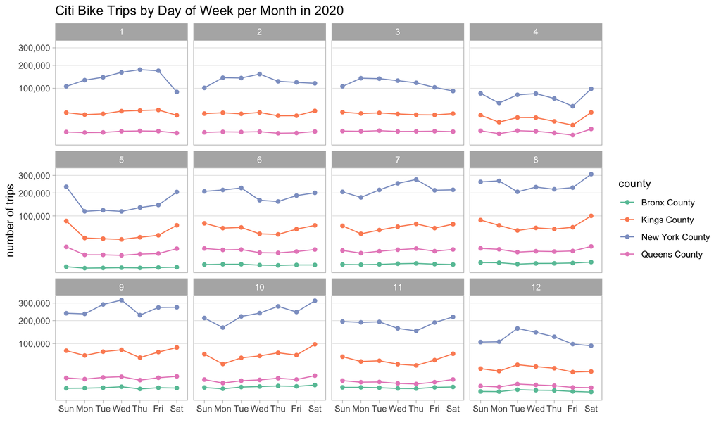

```r
options(scipen=10000)
p <- bike_join %>%
  mutate(month = month(trip_date)) %>%
  group_by(month, day_of_week, county) %>%
  summarize(wday_trips = n()) %>%
  ggplot(aes(x = day_of_week, y = wday_trips, group = county, color = county), data = .) +
  geom_point(aes(color = county)) +
  geom_line(size = 0.5) +
  scale_y_continuous(trans='sqrt',
                     labels = scales::comma)+
  facet_wrap(.~month) +
#  scale_y_continuous(labels = scales::comma) +
  labs(title = "Citi Bike Trips by Day of Week per Month in 2020",
       x = "", y = "number of trips") +
  theme_light() +
  scale_color_brewer(palette = "Set2") +
  theme(panel.grid.minor = element_blank(),
        panel.grid.major.x = element_blank())
p
```

This plot shows the number of Citi Bike trips by day of week per month for each county in 2020. From the graph we can see New York County (Manhattan) has the highest numbers of bike trips all the time among all four counties, following by Kings County (Brooklyn), Queens County, and Bronx County. The difference could be explained by the number of bikes allocated in these areas. In fact, [Citi Bike just expanded to Bronx in May, 2020](https://www.welcome2thebronx.com/2020/05/07/first-citi-bike-stations-have-been-installed-in-the-bronx/).

The trends of bike trips are similar across counties. For example, during winter (Dec, Jan, Feb), in general there were more bike trips in weekdays than in weekends, which probably indicates people used Citi Bikes for commuting to work but not for outdoor biking over the weekends in those time periods. In comparison, during some months (e.g., Apr, May, Aug) there were more bike trips in weekends than weekdays, which probably suggests more people were riding Citi Bikes for weekend activities when Covid restrictions relaxed and weather became warmer.

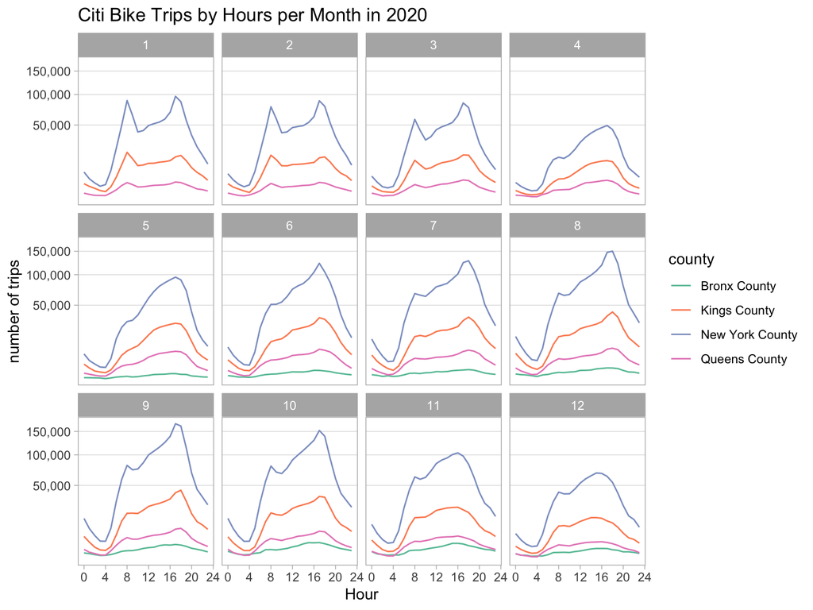

```r
p3 <- bike_join %>%
  filter(gender != 0) %>%
  mutate(gender = as.factor(gender)) %>%
  mutate(month = month(trip_date)) %>%
  mutate(hour = hour(start_time)) %>%
  group_by(month, hour, county) %>%
  summarize(hour_trips = n()) %>%
  ggplot(aes(x=hour, y=hour_trips, group = county, color = county), data = .) +
  geom_line(size = 0.5) +
  facet_wrap(.~month) +
   scale_y_continuous(trans='sqrt',labels = scales::comma)+
  scale_x_continuous(breaks = seq(0,24,4)) +
  scale_color_brewer(palette = "Set2") +
  labs(title = "Citi Bike Trips by Hours per Month in 2020",
       x = "Hour", y = "number of trips") +
  theme_light() +
  theme(panel.grid.minor = element_blank(),
        panel.grid.major.x = element_blank())
p3
```

This graph shows the number of Citi Bike trips by hour per month for each county in 2020.In general, we can see two peaks every day: one at about 7-8 a.m. and the other at about 5 pm, which corresponds to the typical workday schedules. Overall, there were more bike trips after 12 pm (afternoon and evening) than before 12 pm (morning and midnight).

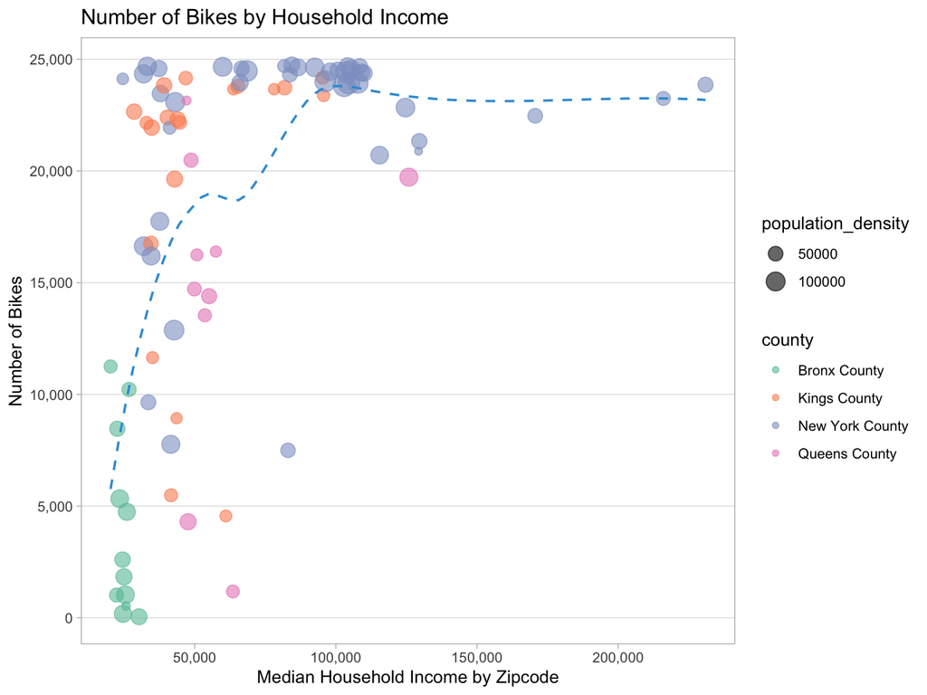

```r
p_income_bike <- bike_join %>%
  group_by(median_household_income, population_density, county) %>%
  summarise(distinct_bike = n_distinct(bike_id)) %>%
  ggplot(aes(x = median_household_income, y = distinct_bike), data = .) +
  geom_point(aes(size = population_density, color = county), alpha = 0.6) +
  scale_color_brewer(palette = "Set2") +
  geom_smooth(color = "#379DDA",se = FALSE, size = 0.7, linetype = 2) +
  scale_x_continuous(labels = scales::comma)+
  scale_y_continuous(labels = scales::comma)+
  labs(y = "Number of Bikes",
       x = "Median Household Income by Zipcode",
       title = "Number of Bikes by Household Income") +
  theme_light() +
   theme(panel.grid.minor = element_blank(),
        panel.grid.major.x = element_blank())
p_income_bike
```

[One problem with Citi Bike](https://ny.curbed.com/2019/7/10/20689177/citi-bike-equity-expansion-report) is that it is reported to disproportionally underserve communities with relatively low median household income compared to wealthy neighborhoods. The above visualization is created to understand whether this phenomenon continues to hold in 2020. The graph plots the number of bikes located in a neighborhood indicated by zipcode against the median household income of the neighborhood. The size of a circle indicates population density in a neighborhood, and the color indicates which county a neighborhood is in. We can see from the graph that neighborhoods in Bronx County, the neighborhoods with lowest median household income, have relatively few number of bikes despite their mid-size population density, while almost all neighborhoods with median household income over $100,000 have plenty of bikes regardless of their population density.